# Attitudes toward Redistribution Thirty Years After: Theoretical and Empirical Reflections on Svallfors’ (1997) Findings

$~$ $~$

#### **Nate Breznau, Lisa Heukamp & Hung H.V. Nguyen**

#### **University of Bremen**

$~$ $~$

## DESCRIPTION

This is an expansion of the work of Svallfors (1997) following an earlier expansion of his work by Linos and West (2003). A replication of his original study is available in our ‘Replication Appendix’ Here we offer our main analyses.

### Abstract

In 1997, Stefan Svallfors “[(1997)](https://doi.org/10.1093/oxfordjournals.esr.a018219)” published, “Worlds of Welfare and Attitudes to Redistribution: A Comparison of Eight Western Nations” in which he analyzed data from the 1992 ‘Social Inequality Module’ of the International Social Survey Program (ISSP). He wanted to understand how attitudes are structured in various welfare regimes. For twenty years, his study has been a standard citation in scholarship on comparative welfare states and social policy preferences. The ISSP was the first macro-comparative survey of policy preferences, and Svallfors’ work was one of the first to compare attitudes toward redistribution in as many as eight countries using the 1992 data (there as a ISSP in 1985 but it only had 5 countries). In this paper we revisit his path-breaking work in light of theories of policy preferences. We replicate his work, we further investigate his measurement and distributional assumptions about attitudes toward redistribtuion, and we then expand his original work to include more recent waves of ISSP data.

GESIS provides the ISSP 1992 ‘Social Inequality’ data “[ZA2310.dta](https://www.gesis.org/issp/modules/issp-modules-by-topic/social-inequality/1992)”.

However, these data have both non-response and the response choice “Can’t choose” coded as missing (“.” in Stata). Therefore, we contaced GESIS and got the file ZA2310_2006-07-18.dta, which we suspect is likely just the old SPSS version transferred into Stata (“[ZA2310_2006-07-18.sav"](https://dbk.gesis.org/dbksearch/sdesc2.asp?no=2310&db=E&tab=3)”)

There was already an expansion of his original study by Linos and West “[2003](https://doi.org/10.1093/esr/19.4.393)” that added gender, marital status, income, years of education and years of ed squared (p. 298).

They also point out that: “As responses to individual questions were constrained to five options, we considered employing a model appropriate for a limited dependent variable. However, the combination of index construction and multiple imputation made OLS appropriate, because the following conditions held. First, the dependent variable was essentially continuous. Even using only actual responses from the data-set, our index permits us to observe the dependent variable at 15 points. Moreover, we imputed even more intermediate values in order to increase the precision of the estimation. Secondly, the distribution of the dependent variable was not truncated or censored.” (p. 397)

They also impute values, we should consider this step carefully.

They only analyze the four countries that Svallfors ‘selects’ due to missing data. We should consider finding a way to analyze all eight.

### The Original Svallfors Study

**His original study used three questions:**

1. It is the responsibility of the government to reduce the differences between people with high incomes and those with low incomes? –> v57
2. The government should provide a job for everyone who wants one? –> v59
3. The government should provide everyone with a guaranteed basic income? –> v62

**He constructed a “government index” scale from the three questions as follows:**

*“For this purpose, an additive index was constructed from the three items, dividing between ‘strongly agree’ and ‘agree’ (2); ‘neither agree nor disagree’ (1); and ‘disagree’ and ‘strongly disagree’ (0). These items were summed, creating an index which may vary between 0 and 6, where 0 means disagreeing with all three propositions and thereby endorsing a clear-cut anti-interventionist stand and 6 means a strong interventionist standpoint“* (Svallfors 1997: 289).

**He used eight country cases:**

Swe, Nor, Ger, Aut, Aus, Nz, Can, USA Theese are in v3 coded as Swe=10,Nor=9,GermanyW=2,Aut=6,Aus=1,NZ=16,Can=17,US=5

## SETUP

### Dependent Variable

It seems like Linos and West (2003, p. 398, “We imputed even more intermediate values…”) imputed DV values. We are hesitant to do this; however, we should consider a maximum likelihood estimation routine

```r
# code higher vales to more agreement (8="can't choose")
issp92$v57 <- car::recode(issp92$v57,recodes = '1=5; 2=4; 3=3; 4=2; 5=1; 8=8; 9=NA')
issp92$v59 <- car::recode(issp92$v59,recodes = '1=5; 2=4; 3=3; 4=2; 5=1; 8=8; 9=NA')
issp92$v62 <- car::recode(issp92$v62,recodes = '1=5; 2=4; 3=3; 4=2; 5=1; 8=8; 9=NA')
```

### Independent Variables

#### Class Scheme Coding

```r
#here we replicate the class scheme

#we thought we could get the scheme from the cumulative ISSP

isspCUM <- read_dta(paste(wd, "ZA5890_v1-0-0.dta", sep = ""))
df2 <- isspCUM[which(isspCUM$V5 %in% c(752, 578, 276, 40, 36, 554, 124, 840) & isspCUM$V4 == 1992),]
df2 <- df2[,c("V3","ISCO88")]

#but there are no ISCO88 codes for 1992 so we are stuck with the Swedish coding
#It uses NYK 'Nordic Occupational Classification System

df2 <- dplyr::rename(df2, v2 = V3)

df <- as.data.frame(left_join(issp92, df2, by = "v2"))
```

```
Column `v2` has different attributes on LHS and RHS of joinColumn `v2` has different attributes on LHS and RHS of joinColumn `v2` has different attributes on LHS and RHS of join
```

```r
df$v110 <- car::recode(df$v110, recodes = '2=0')

#Here is the NYK scheme for Sweden (variable s106)
#It appears that Svallfors' original data was SEI classification (2-digit), but that provided in the ISSP from GESIS is NYK83
#we use Erik Bihagen's translation of NYK into ISCO88 [although they are not perfectly transferrable!!] http://www.camsis.stir.ac.uk/occunits/SwedishNYK8590majgpsv1.sps

df$isco88se <- car::recode(df$s106, recodes = "
1 = 2141; 2 = 2143; 3 = 2144; 4 = 2145; 5 = 3116; 6 = 3117; 7 = 2142; 8 = 2148; 9 = 3119; 12 = 3211; 13 = 3211; 14 = 2114; 15 = 2112; 16 = 2113; 19 = 3111; 21 = 2211; 22 = 3213; 23 = 3213; 29 = 2211; 30 = 1210; 31 = 2310; 32 = 2320; 33 = 2331; 34 = 2320; 35 = 2359; 36 = 2320; 37 = 2352; 39 = 2359; 41 = 2460; 49 = 3480; 51 = 2421; 52 = 2429; 53 = 2429;
54 = 2429; 59 = 2429; 61 = 2451; 62 = 1234; 63 = 1229; 69 = 2451; 71 = 2452; 72 = 3471; 73 = 3471; 74 = 3131; 75 = 3474; 76 = 2453; 77 = 2455; 79 = 2455; 91 = 2432; 92 = 2431; 99 = 2446; 101 = 2221; 102 = 2230; 103 = 3231; 104 = 3232; 105 = 3133; 106 = 5132; 107 = 5132; 109 = 9132; 111 = 3226; 112 = 2229; 119 = 3226; 121 = 2222; 122 = 3225; 123 = 3225; 129 = 3225; 131 = 2224; 139 = 3228; 141 = 2223; 149 = 3227; 151 = 2446; 152 = 1228; 153 = 5131; 154 = 5133; 155 = 1228; 159 = 2446; 161 = 3152; 162 = 3151; 169 = 3152; 191 = 2445; 192 = 3223; 199 = 3460; 201 = 1110; 202 = 3443; 203 = 3444; 209 = 1110; 211 = 2419; 212 = 3431; 219 = 2419; 221 = 2412; 222 = 3423; 229 = 2412; 231 = 2411; 232 = 2411; 239 = 4121; 241 = 4115; 242 = 4111; 249 = 4190; 251 = 2131; 252 = 3122; 259 = 3121; 261 = 2441; 262 = 2122; 269 = 2441; 291 = 4190; 292 = 4122; 293 = 3412; 294 = 3412; 295 = 4221; 296 = 3422; 297 = 1317; 299 = 4190; 311 = 3471; 312 = 3413; 313 = 3419; 319 = 3419; 321 = 3416; 331 = 1314; 332 = 5220; 333 = 5220; 339 = 5220; 399 = 5220; 400 = 1311; 401 = 6112; 402 = 6130; 403 = 6130; 404 = 6130; 405 = 6130; 406 = 6129; 409 = 6112; 411 = 6112; 412 = 6121; 413 = 6112; 414 = 6129; 419 = 6121; 421 = 6154; 431 = 6152; 432 = 6151; 439 = 6152; 441 = 6141; 449 = 6141; 501 = 7111; 509 = 7111; 511 = 8113; 521 = 8121; 531 = 8155; 599 = 7111; 601 = 3142; 602 = 3142; 603 = 3141; 609 = 3142; 611 = 8340; 612 = 8340; 619 = 8340; 621 = 3143; 629 = 3143; 631 = 8311; 640 = 8322; 641 = 8324; 642 = 8322; 643 = 9151; 649 = 8334; 651 = 3144; 652 = 5112; 653 = 5111; 659 = 5112; 661 = 4133; 662 = 3144; 663 = 8312; 664 = 4133; 669 = 4133; 671 = 4142; 673 = 3132; 674 = 3132; 675 = 3132; 679 = 4142; 681 = 4142; 682 = 9151; 689 = 4142; 691 = 4133; 699 = 9330; 701 = 8261; 702 = 7332; 703 = 7432; 705 = 8262; 706 = 7435; 707 = 3152; 709 = 7332; 711 = 7433; 712 = 7434; 713 = 7433; 714 = 7437; 715 = 7435; 716 = 7433; 719 = 7436; 721 = 7442; 722 = 7442; 723 = 8268; 729 = 8269; 731 = 8121; 732 = 8122; 733 = 8122; 735 = 7215; 736 = 7221; 737 = 7211; 739 = 8122; 741 = 7311; 742 = 7311; 743 = 3224; 744 = 3211; 745 = 7313; 746 = 7323; 749 = 7222; 751 = 8211; 752 = 7233; 753 = 7231; 754 = 7213; 755 = 7136; 756 = 7212; 757 = 7214; 758 = 8223; 759 = 7214; 761 = 7241; 762 = 7241; 763 = 8282; 764 = 7244; 765 = 7245; 766 = 3131; 769 = 8282; 771 = 6141; 772 = 8141; 773 = 8240; 775 = 7331; 776 = 7331; 777 = 7423; 779 = 8141; 781 = 7141; 782 = 7132; 783 = 7141; 789 = 7139; 791 = 7122; 793 = 7123; 794 = 7124; 795 = 7134; 796 = 7135; 799 = 7129; 801 = 7341; 802 = 7343; 803 = 8251; 804 = 7345; 805 = 8224; 809 = 8251; 811 = 7322; 812 = 7321; 813 = 8131; 814 = 7323; 819 = 8139; 821 = 8273; 822 = 7412; 823 = 8274; 824 = 8278; 825 = 9320; 826 = 7411; 827 = 8272; 828 = 8279; 829 = 8278; 831 = 8159; 832 = 8151; 833 = 8151; 834 = 8231; 835 = 8232; 839 = 8159; 841 = 8142; 842 = 8143; 843 = 8253; 849 = 8142; 851 = 7129; 852 = 8265; 853 = 7312; 854 = 7113; 859 = 7222; 861 = 8161; 869 = 8161; 871 = 8333; 872 = 8332; 873 = 8334; 879 = 9330; 881 = 9320; 882 = 9330; 889 = 9320; 891 = 9151; 901 = 5161; 902 = 9162; 903 = 5162; 904 = 3441; 905 = 5163; 906 = 5169; 909 = 5169; 911 = 1225; 912 = 5122; 913 = 5123; 914 = 5123; 915 = 4222; 916 = 5111; 919 = 5123; 921 = 5121; 929 = 5121; 931 = 9141; 932 = 9131; 939 = 9141; 941 = 5141; 942 = 5149; 949 = 5141; 951 = 9133; 952 = 9133; 959 = 9133; 961 = 3475; 971 = 5143; 979 = 5149; 981 = 110; 989 = 110")

#now merge the imputed SE ISCO
df$ISCO88 <- ifelse(df$v3==10,df$isco88se,df$ISCO88)

df$egp <- occupar::isco88toEGP(df$ISCO88, self.employed = df$v110, n.employees = df$v108)

df <- df %>%
  mutate(
    egp6 = car::recode(egp, recodes = '"I     Service class I" = "Service I";"II    Service class II" = "Service II"; "III.a Routine non-manual, higher grade" = "Routine"; "III.b Routine non-manual, lower grade" = "Routine"; "IV.a  Self-employed with employees" = "Self"; "IV.b  Self-employed with no empoyees" = "Self"; "IV.c  Self-employed Farmers etc" = "Self"; "V     Manual supervisors/Lower grade technicians" = "Skilled";"VI    Skilled workers" = "Skilled"; "VII.a Unskilled workers" = "Unskilled"; "VII.b Farm labours" = "Unskilled"')
  ) #V Manual supervisors = Skilled in Svallfors' original coding.
```

#### Income

```r
df$hhinc <- coalesce(df$cdn116,df$s117,df$usa116,df$n116,df$a116,df$aus116,df$nz116,df$d116)
df$hhinc <- car::recode(df$hhinc,recodes = '97:99=NA')

# Standardize income per country
  # The HH income is measured on different scales, this is a rough and relative measure
  # Sweden did not ask household income, this is also a problem. Use respondent's income for now.

df <- df %>%
  group_by(v3) %>%
  mutate(
    hhinc_gz = scale(hhinc))
```

#### Other SES & Demographics

```r
#Canada missing ed in years, impute, best guess (1=none, 2= grade school, 3= some high, 4=hs complete, 5=some college, 6= college complete, 7=university complete, 8=grad school)
df$cdn103 = car::recode(df$cdn103,recodes = '1=4; 2=8; 3=10; 4=12; 5=14; 6=16; 7=17; 8=20; 99=NA')
#Sweden impute (1=primary, 2=secondary(2 years), 3=secondary(3 years), 4= university)
df$s103 = car::recode(df$s103,recode = '1=8; 2=10; 3=12; 4=15; 99=NA')
#Swe=10,Nor=9,GermanyW=2,Aut=6,Aus=1,NZ=16,Can=17,US=5
df$cntry = car::recode(df$v3,recodes = '10=752; 9=578; 2=276; 1=36; 6=40; 16=554; 17=124; 5=840; 3:4=NA; 7:8=NA; 11:15=NA; 18=NA')
df$female = car::recode(df$v99,recodes = '2=0; 9=NA')
#trim age to 80
df$age = car::recode(df$v100,recodes = '80:98=80; 99=NA')
#Married (not separted) and Widowed = partnered, all else = 'not partnered')
df$partnered = car::recode(df$v101,recodes = '1:2=1; 3:9=0')

df$s103 <- ifelse(is.na(df$s103), df$cdn103, df$s103)
df$v102 <- ifelse(is.na(df$v102), df$s103, df$v102)

# Select only the 8 countries
df <-df[complete.cases(df$cntry),]
```

### Create Listwise Dataframe

```r
# Create a listwise deleted df
df_list <-df[complete.cases(df$v57),]
df_list <-df_list[complete.cases(df_list$v59),]
df_list <-df_list[complete.cases(df_list$v62),]
```

## Measuring “Redistributive Attitudes”

Classic attitude theory suggests that agree/disagree (or ‘Likert’ type response questions) tend to be normally distributed around some mean. In fact, latent variable measurment of attitudes also tends toward this assumption. Svallfors forces the three ISSP questions into somewhat dichotomous distributions by collapsing the two agree categories and the two disagree categories. It leads to a bit of a U-shape. However, then he combines the three collapsed variables into one additive scale. Generally linear scaling practices lead to continuous variables.

After working with lavaan for some time it became clear that there are too many limitations. lavaan cannot do an efficient exploratory factor analysis, handle dichotomous latent variable outcomes (i.e. ‘latent class analysis’), and is limited in its multi-group modelling. Therefore, we need to use Mplus to fully investigate Svallfors’ scale.

### ISSP Question Distributions

Visualize the distribution of the three questions.

[figure not shown]

```r
df_list$v57f <- as.factor(df_list$v57)
df_list$v59f <- as.factor(df_list$v59)
df_list$v62f <- as.factor(df_list$v62)

ggplot(df_list, aes(v57f)) +
  geom_bar(fill = "gray40") +
  scale_x_discrete("Original Response Choices (non-response omitted)", labels = c("Strongly disagree","Disagree","Neutral","Agree" ,"Strongly agree","Can't choose")) +
  ggtitle("Gov. Provide Jobs for Everyone that Wants One")
```

```r
jobsdf <- dplyr::select(df_list, v57f)
jobsdf$var <- jobsdf$v57f
jobsdf$Item <- "Jobs"
incddf <- dplyr::select(df_list, v59f)
incddf$var <- incddf$v59f
incddf$Item <- "Income Dif."
bascdf <- dplyr::select(df_list, v62f)
bascdf$var <- bascdf$v62f
bascdf$Item <- "Basic Income"

dfdist <- rbind(jobsdf,incddf,bascdf)
```

```
Vectorizing 'haven_labelled' elements may not preserve their attributesVectorizing 'haven_labelled' elements may not preserve their attributesVectorizing 'haven_labelled' elements may not preserve their attributes
```

[figure not shown]

```r
dfdist$Item <- factor(dfdist$Item, levels = c("Jobs","Income Dif.","Basic Income"))

ggplot(dfdist, aes(fill=Item, x=var)) +
    geom_bar(position="dodge", stat="count") +
    scale_x_discrete("Original Response Choices (non-response omitted)", labels = c("Strongly disagree","Disagree","Neutral","Agree" ,"Strongly agree","Can't choose")) +
    ggtitle("Figure 1. Response Pattern in Three Redistribution Questions", subtitle = "ISSP 1992, 8 Countries") +
    scale_fill_manual(values=c("grey70","grey45","grey20"))
```

### Test for Response Intervals

We run an ordered logistic regression (ologit) to test what the cutpoints look like. The ologit assumes an underlying normally distributed latent variable and then fits the ordered categories into this distribution. The cutpoints are the locations on the distribution that divide each of the 5 respones into ‘zones’ of the distribution.

```r
brant(ologit_jobsb)
```

```
--------------------------------------------
Test for    X2  df  probability
--------------------------------------------
Omnibus     107.59  33  0
female      19.06   3   0
age     28.37   3   0
partnered   1.02    3   0.8
edyrs       12.5    3   0.01
edyrs2      12.72   3   0.01
egp6Self    8.08    3   0.04
egp6Service I   0.77    3   0.86
egp6Service II  0.18    3   0.98
egp6Skilled 3.68    3   0.3
egp6Unskilled   2.64    3   0.45
hhinc_gz    4.86    3   0.18
--------------------------------------------

H0: Parallel Regression Assumption holds                        X2 df  probability
Omnibus        107.5936018 33 7.784460e-10
female          19.0629917  3 2.653208e-04
age             28.3656576  3 3.043580e-06
partnered        1.0194636  3 7.965425e-01
edyrs           12.5027295  3 5.845235e-03
edyrs2          12.7159323  3 5.292981e-03
egp6Self         8.0823278  3 4.434053e-02
egp6Service I    0.7655122  3 8.576970e-01
egp6Service II   0.1755207  3 9.814409e-01
egp6Skilled      3.6797139  3 2.981908e-01
egp6Unskilled    2.6403572  3 4.504583e-01
hhinc_gz         4.8563880  3 1.826203e-01
```

### Cut Points

```r
cptdf <- data.frame(matrix(ncol = 4, nrow = 6))

cptdf[1,1:3] <- -4
cptdf[6,1:3] <- 4
cptdf[2,1] <- ologit_jobs[["zeta"]][["1|2"]]
cptdf[3,1] <- ologit_jobs[["zeta"]][["2|3"]]
cptdf[4,1] <- ologit_jobs[["zeta"]][["3|4"]]
cptdf[5,1] <- ologit_jobs[["zeta"]][["4|5"]]

cptdf[2,2] <- ologit_incd[["zeta"]][["1|2"]]
cptdf[3,2] <- ologit_incd[["zeta"]][["2|3"]]
cptdf[4,2] <- ologit_incd[["zeta"]][["3|4"]]
cptdf[5,2] <- ologit_incd[["zeta"]][["4|5"]]

cptdf[2,3] <- ologit_basic[["zeta"]][["1|2"]]
cptdf[3,3] <- ologit_basic[["zeta"]][["2|3"]]
cptdf[4,3] <- ologit_basic[["zeta"]][["3|4"]]
cptdf[5,3] <- ologit_basic[["zeta"]][["4|5"]]


cptdf[1,4] <- cptdf[2,1] + ((cptdf[1,1] - cptdf[2,1])/2)
cptdf <- round(cptdf,2)

# We assume that our normal distribution runs form -4 SD though 4 SD (this covers 99.9% of the population)
# Thus the cutpoints we get are splits on a scale from -4 through 4 (see Figure below)
# We can imagine estimates on a normally distributed underlying 'attitude' that are the midpoints of -4 to cutpoint 1 / cut 1 to cut 2 / and so forth...

###### We can fill this in later in case we want to run analyses with unequal coded intervals

cptdf$X4 <- cptdf$X4 + 3.23

xv = seq(-4,4, length = 1000)
yv = dnorm(xv)
```

Tukey talks about how many scales are technically ordinal when taking the most orthodox empirical position, but that the gains we make in estimation of ordinal scales as ‘the correct form’ are overshadowed by the losses we incur when not using an interval dependent variable in our models. So long as the ordinal variable has good theoretical (‘face-value’) properties to be interval and demonstrates reasonable statitical properties as such, we should use it that way or at least estimate both ways. See here for citations or quotes: https://www.cs.uic.edu/~wilkinson/Publications/stevens.pdf

Also

Mohler, Peter Ph., Tom W. Smith, Janet Harkness, and Janet Harkness. 1998. “Respondents’ Ratings of Expressions from Response Scales: A Two-Country, Two-Language Investigation on Equivalence and Translation.” Pp. 159–84 in Cross-Cultural Survey Equivalence. Vol. 3. Mannheim: Zentrum für Umfragen, Methoden und Analysen -ZUMA-.

found using cognitive survey instrument testing of similar 5-ctegory agree/disagree response scales in that the option ‘can’t choose’ is like a neutral midpoint, at least in the German and US-American context.

they also found that the cognitive mapping of the meaning of responses differed between Germans and Americans to some extent (amount of descriptive words and intensity of wording). This is slight evidence of non-invariance of these questions across societies.

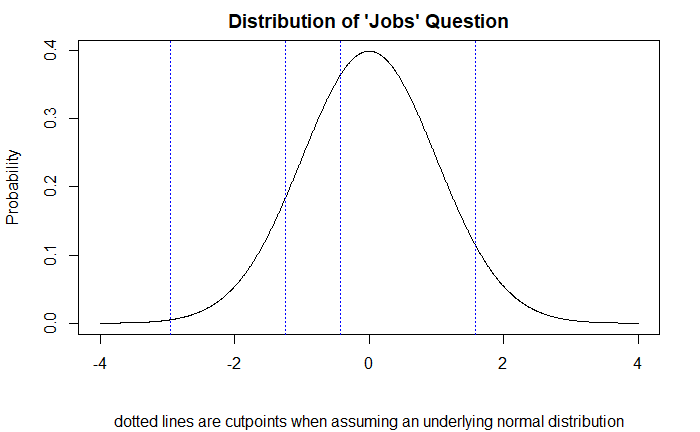

```r
plot(xv, yv, type="l", lty=1, xlab="", ylab="Probability", main="Distribution of 'Jobs' Question", sub="dotted lines are cutpoints when assuming an underlying normal distribution")
abline(v=cptdf[2,1], col="blue", lty = "dotted")
abline(v=cptdf[3,1], col="blue", lty = "dotted")
abline(v=cptdf[4,1], col="blue", lty = "dotted")
abline(v=cptdf[5,1], col="blue", lty = "dotted")

# Income Differences
plot(xv, yv, type="l", lty=1, xlab="", ylab="Probability", main="Distribution of 'Income Differences' Question", sub="dotted lines are cutpoints when assuming an underlying normal distribution")

abline(v=cptdf[2,2], col="blue", lty = "dotted")
abline(v=cptdf[3,2], col="blue", lty = "dotted")
```

[figure not shown]

```r
abline(v=cptdf[4,2], col="blue", lty = "dotted")
abline(v=cptdf[5,2], col="blue", lty = "dotted")
```

```r
# Basic Income
plot(xv, yv, type="l", lty=1, xlab="", ylab="Probability", main="Distribution of 'Basic Income' Question", sub="dotted lines are cutpoints when assuming an underlying normal distribution")
abline(v=cptdf[2,3], col="blue", lty = "dotted")
```

```r
abline(v=cptdf[3,3], col="blue", lty = "dotted")
abline(v=cptdf[4,3], col="blue", lty = "dotted")
```

[figure not shown]

```r
abline(v=cptdf[5,3], col="blue", lty = "dotted")
```

We can see that the distribution when taking the three questions and combining them with equal weighting and then roundig to the nearest value, we get a slightly skewed normal distribution. It looks like what we would expect form attitude research.

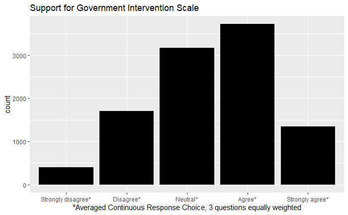

### Table A. Correlations

In this chunk we create an export .dat file for Mplus, in addition to looking at the correlations between the attitude variables and a few criterion variables.

```r
# Correlation commands are easier when the data.frame has only the variables of interest.

socIn92cor <- as.data.frame(dplyr::select(socIn92recode, v57, v59, v62, r1, r2, r3, v3, v99, v100, v102, s103, cdn103))

# output Mplus data (future iterations should include missing values)
# does not accept haven attributes, remove them by exporting to csv and reimporting
write.csv(socIn92cor, file = "svtemp.csv")
socinm <- as.data.frame(read.csv(file = "svtemp.csv"))
unlink("svtemp.csv")


prepareMplusData(socinm, filename = "svallfors.dat", inpfile = T)

cor <- cor(socIn92cor)
# This keeps only one side of the diagonal
cor[upper.tri(cor, diag=TRUE)] <- as.numeric("")

options(knitr.kable.NA = '')
t10 <- knitr::kable(cor,format="html", digits = round(2), col.names = c("IncD_5","Jobs_5","BasicI_5","IncD_3","Jobs_3","BasicI_3","Country","Male","Age","Ed_Years"), caption = "Table 10. Correlations of Original and Recoded ISSP Questions from Svallfors (1997)")

column_spec(t10, 2:10, "5em")
```

[output not shown]

The basic three factor scale is “just identified”, this means it has as many estimated parameters as observed parameters. This means there is no possibility to use the global chi-square fit test. We thus have to rely on indices (AIC, Log-likelihood) to compare models.

## Import results from Mplus

```r
lca2 <- readModels("C:/GitHub/Svallfors-1997-Replication/svallfors1lcac2.out", recursive = TRUE)
lca3 <- readModels("C:/GitHub/Svallfors-1997-Replication/svallfors1lcac3.out", recursive = TRUE)
lca4 <- readModels("C:/GitHub/Svallfors-1997-Replication/svallfors1lcac4.out", recursive = TRUE)
lca5 <- readModels("C:/GitHub/Svallfors-1997-Replication/svallfors1lcac5.out", recursive = TRUE)
```

### Measurement Models

Prep data for SEM, separate data.frames for each SEM seems to work best. Also, attributes must be removed for lavaan to operate properly.

```r
# How well do the attitude measures predict Svallfors' gov index

fitgovindex <- lm(att_sval1 ~ v57 + v59 + v62 ,data = socIn92recodeM)
lm.beta(fitgovindex)

# Inspect residuals

socIn92recodeM$fgovp <- predict(fitgovindex)
socIn92recodeM$resid <- socIn92recodeM$fgovp - socIn92recodeM$att_sval1
```

[output not shown]

### Plotted Residuals of Svallfors’ variables and the Fitted Factor

```r
# They do not follow a normal distribution

hist(socIn92recodeM$resid, breaks = 20)
```

[output not shown]

### The values of the fitted factor (quasi normally distributed, no?)

```r
hist(socIn92recodeM$fgovp, breaks = 20)
```

[output not shown]

```r
# How well do Svallfors recoded measures predict gov index
fitgovindex2 <- lm(att_sval1 ~ r1 + r2 + r3 ,data = socIn92recodeM)
lm.beta(fitgovindex2)
```

[output not shown]